# Statistical Inference Course Project

## Assignment

In this project we will investigate the exponential distribution in R and compare it with the Central Limit Theorem. The exponential distribution can be simulated in R with rexp(n, lambda) where lambda is the rate parameter. The mean of the exponential distribution is:

$\mu = 1/\lambda$

and the standard deviation is

$\sigma = 1/\lambda$.

```r
nsamples <- 1000
lambda <- rep(0.2, nsamples)
sample_size <- 40
```

Set $\lambda = 0.2$ for all of the simulations. We will investigate the distribution of averages of 40 exponentials. Note that we will do 1000 simulations.

We will illustrate via simulation and associated explanatory text the properties of the distribution of the mean of 40 exponentials. We will

1. Show the sample mean and compare it to the theoretical mean of the distribution.
2. Show how variable the sample is (via variance) and compare it to the theoretical variance of the distribution.
3. Show that the distribution is approximately normal.

## Overview

This task demonstrates the central limit theorem, which states the distribution of the sample means follows the central limit theorem, which states:

- mean of sample means = $\bar{X} = \sigma$
- sd of sample means = $s = \sigma/\sqrt{n}$
- where n is the sample size
- and sample means are normally (gaussian) distributed regardless of the population distribution, exponential in this case

We do this by obtaining 1000 samples of sample size 40 from a population exponentially distributed with lambda (rate) of 0.2.

If we define the exponential random variables as $X$, and the random variables representing the sample means as $Y$,

According to the central limit theorem, the distribution of the means of the $n_Y = 1000$ samples should be normally distributed with mean $\mu_Y = 1/\lambda$ and standard deviation $\sigma_Y = (1/\lambda)/\sqrt{n_X}$.

With $\lambda = 0.2$, this translates to $\mu_Y = 5$ and $\sigma_Y = 0.7905694$.

## Simulations

: Include English explanations of the simulations you ran, with the accompanying R code. Your explanations should make clear what the R code accomplishes.

```r
samples <- lapply(lambda, function(x) rexp(sample_size, x))
```

The following code calculates the means and standard deviations of the sample means, $\bar{Y}$, and $s_Y$.

```r
means <- sapply(samples, mean) # vector of length 1,000 (length(means))
sample_means = mean(means) # approx 1/lambda = 1/0.2 = 5
print(sample_means)
```

```
## [1] 4.976754
```

```r
sample_sds = sd(means) # approx 5/sqrt(40) = 5/6.25 = 0.8
print(sample_sds)
```

```
## [1] 0.7823584
```

These are close to the theoretical mean and standard deviation, respectively, which are calculated in the next section.

## Sample Mean versus Theoretical Mean

: Include figures with titles. In the figures, highlight the means you are comparing. Include text that explains the figures and what is shown on them, and provides appropriate numbers.

The following code generates a histogram of the sample means overlaid with a normal distribution with the theoretical mean and sd of the sample means.

```r
theoretical_mean_of_means = 1/lambda[1]
print(theoretical_mean_of_means)
```

```
## [1] 5
```

```r
theoretical_sd_of_means = (1/lambda[1])/sqrt(sample_size)
print(theoretical_sd_of_means)
```

```
## [1] 0.7905694
```

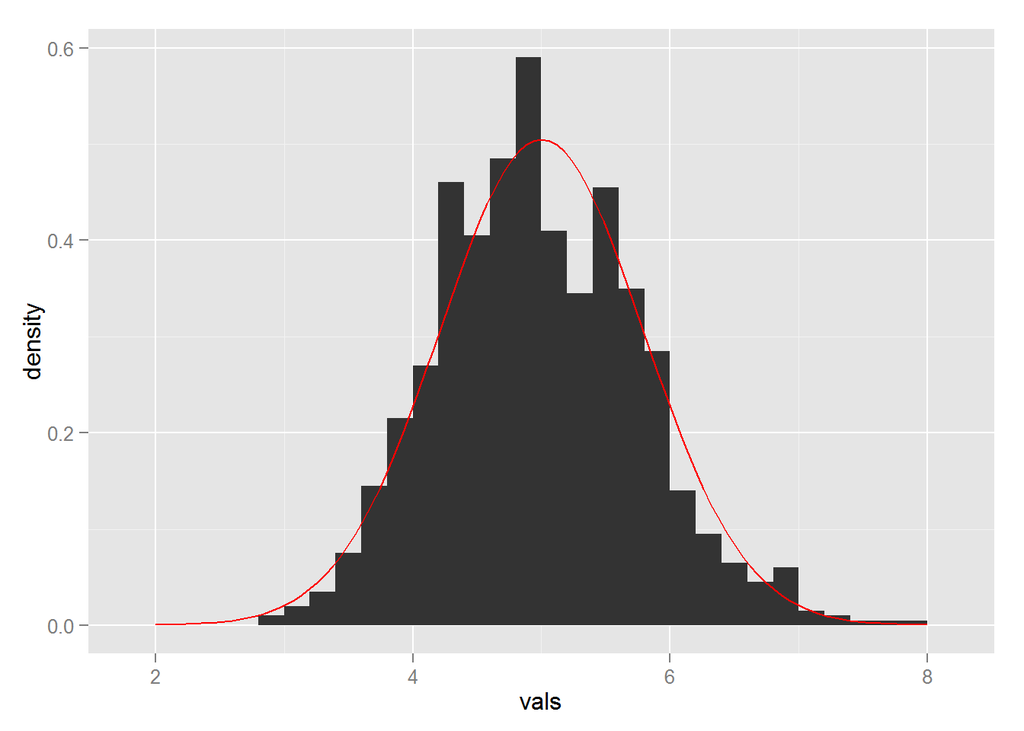

```r
normPlot <- plotFunction(dnorm)
p <- normPlot(means, list(mean=theoretical_mean_of_means, sd=theoretical_sd_of_means))
print(p)
```

By inspection, the plot suggests the means are normally distributed with

$\mu=\bar{Y}$ and $\sigma=s_X/\sqrt{n_X}$.

The 95% confidence interval for $\mu_Y$ is

$\bar{Y} \pm z_{0.025} \times \sigma_X/\sqrt{n_X}$.

Which is:

```r
mean(means) + c(-1,1) * qnorm(0.975) * sd(means)/sqrt(sample_size)
```

```
## [1] 4.734303 5.219205
```

Given this, we can see the theoretical mean $\mu_X = \mu_Y = \mu = 5$ is within the 95% confidence interval.

## Sample Variance versus Theoretical Variance

: Include figures (output from R) with titles. Highlight the variances you are comparing. Include text that explains your understanding of the differences of the variances.

The CLT states the mean of the means is estimated by $\bar{Y}$. It also states the sd of the means is estimated by $\sigma_Y = \sigma_X/\sqrt{n_X}$

Therefore, given $Y$ ~ $N(\mu_Y, \sigma_{Y}^{2})$,

$(n_Y-1)s_Y^2/\sigma_Y^2$ ~ $\chi^2(n_Y-1)$

A $(1-\alpha)100\%$ confidence interval for $\sigma_{Y}^2$ is

${\large\frac{(n_Y-1)s_Y^2}{\chi^2(n_Y-1)_a}} < \sigma_Y^2 < {\large\frac{(n_Y-1)s_Y^2}{\chi^2(n_Y-1)_b}}$. *Verify this formula*

In this case, $n_Y =$ 1000. Taking the square root of both sides to convert from the variance to the standard deviation,

```r
sigma_ci <- sqrt(c((nsamples-1) * sd(means)**2/qchisq(0.975, nsamples-1),
                   (nsamples-1) * sd(means)**2/qchisq(0.025, nsamples-1)))
print(sigma_ci)
```

```
## [1] 0.7495090 0.8182416
```

$\sigma_Y = \sigma_X/\sqrt{n_X} =$

```r
1/lambda[1]/sqrt(sample_size)
```

```
## [1] 0.7905694
```

is within this confidence interval.

Also, $\sigma_Y^2$ in this formula is equal to $\sigma_X^2/n_X$ where $n_X = 40$.

Solving for $\sigma_X$ by multiplying both sides by $\sqrt{40}$, the 95% confidence interval for $\sigma_X$ is:

```r
sqrt(40) * sigma_ci
```

```
## [1] 4.740311 5.175014
```

$\sigma_X = 5$, which is within this confidence interval.

## Distribution

: Via figures and text, explain how one can tell the distribution is approximately normal.

The histogram of the means overlaid with the normal plot is shown again below. This is compared with a histogram of all 40,000 negative exponentials as a single sample, overlaid with an exponential distribution with $\lambda=0.2$. This is clearly exponentially distributed.

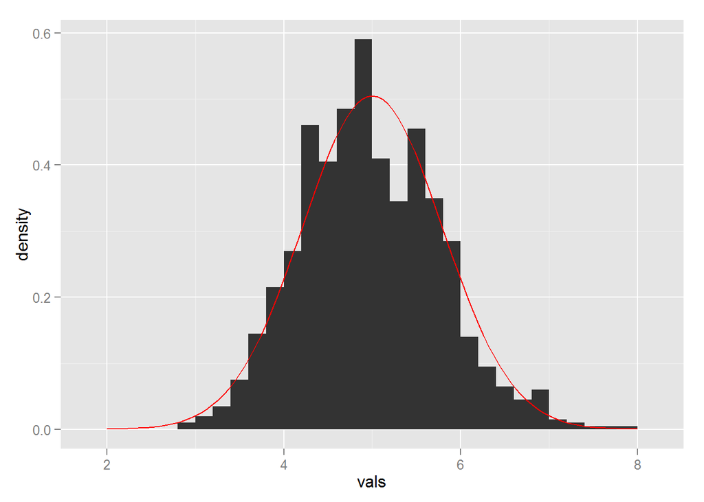

```r
print(p)
```

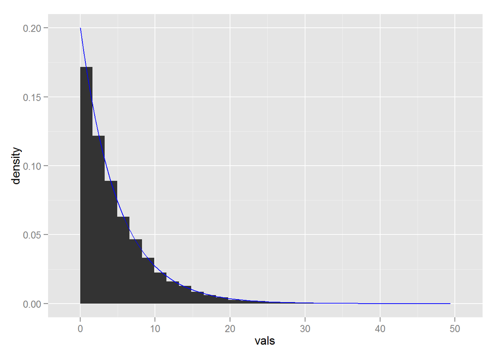

```r
expPlot <- plotFunction(dexp, pl=seq(0,30))
s <- unlist(samples)
ep <- expPlot(s, list(rate=0.2), col="blue")
print(ep)
```